# Data analysis: Nup98 and its interacting DExH/D-box helicases bind similar mRNAs and gene loci

Overlap tests:

```r
pt5 <- overlapPermTest(A=peaks[[2]], B=peaks[[5]], ntimes=1000)
pt6 <- overlapPermTest(A=peaks[[2]], B=peaks[[1]], ntimes=1000)
pt7 <- overlapPermTest(A=peaks[[2]], B=peaks[[3]], ntimes=1000)
pt8 <- overlapPermTest(A=peaks[[2]], B=peaks[[4]], ntimes=1000)
```

Now for the results. Let’s begin with the control DDX11

```r
pt5
```

```
$numOverlaps
P-value: 0.154845154845155
Z-score: 1.0808
Number of iterations: 1000
Alternative: greater
Evaluation of the original region set: 51
Evaluation function: numOverlaps
Randomization function: randomizeRegions

attr(,"class")
[1] "permTestResultsList"
```

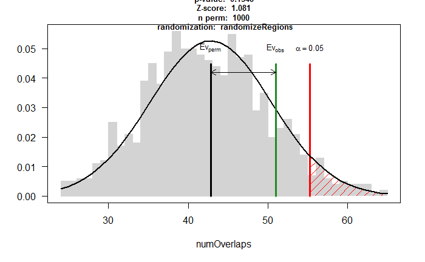

```r
plot(pt5)
```

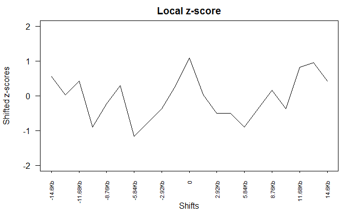

```r
lz <- localZScore(pt=pt5, A=peaks[[2]], B=peaks[[5]])
plot(lz)
```

Now for the Nup98 truncation and Nup98 FL overlap:

```r
pt6
```

```
$numOverlaps
P-value: 0.000999000999000999
Z-score: 162.3485
Number of iterations: 1000
Alternative: greater
Evaluation of the original region set: 1079
Evaluation function: numOverlaps
Randomization function: randomizeRegions

attr(,"class")
[1] "permTestResultsList"
```

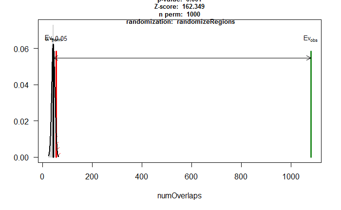

```r
plot(pt6)
```

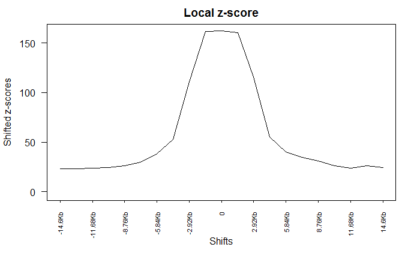

```r
lz <- localZScore(pt=pt6, A=peaks[[2]], B=peaks[[1]])
plot(lz)
```

Up next the nucleoplasmic Nup98 and DDX21.

```r
pt7
```

```
$numOverlaps
P-value: 0.000999000999000999
Z-score: 22.3077
Number of iterations: 1000
Alternative: greater
Evaluation of the original region set: 485
Evaluation function: numOverlaps
Randomization function: randomizeRegions

attr(,"class")
[1] "permTestResultsList"
```

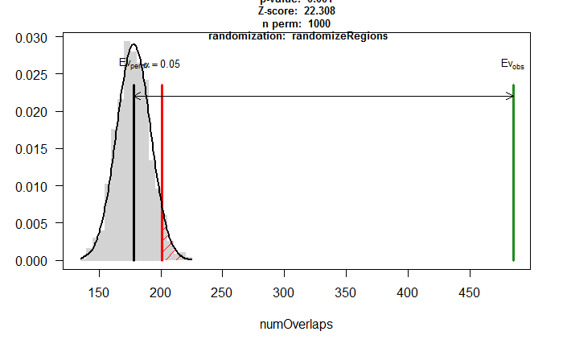

```r
plot(pt7)
```

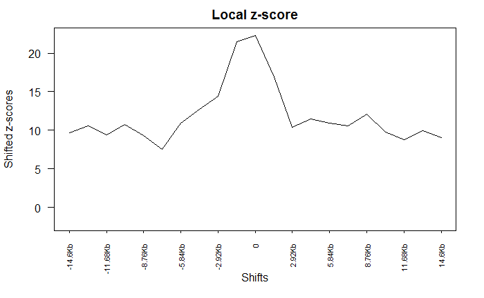

```r
lz <- localZScore(pt=pt7, A=peaks[[2]], B=peaks[[3]])
plot(lz)
```

Finally the nucleoplasmic Nup98 and DDX5

```r
pt8
```

```
$numOverlaps
P-value: 0.000999000999000999
Z-score: 57.5999
Number of iterations: 1000
Alternative: greater
Evaluation of the original region set: 445
Evaluation function: numOverlaps
Randomization function: randomizeRegions

attr(,"class")
[1] "permTestResultsList"
```

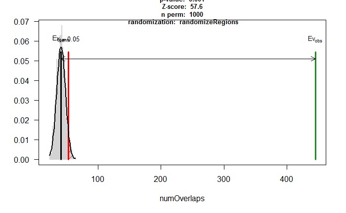

```r
plot(pt8)
```

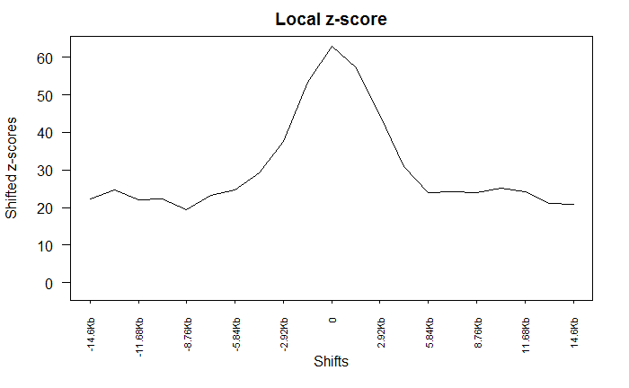

```r
lz <- localZScore(pt=pt6, A=peaks[[2]], B=peaks[[4]])
plot(lz)
```

We need to adjust the obtained p-values to account for the multiple comparisons performed above. Then, we can sumarize the results above in a table below:

```r
Nup98_construct <- c(rep("Full-length",3),rep("Nucleoplasmic_1-504",3))
DBP <- rep(c("DDX11","DDX21","DDX5"),2)
Nup98_interactor <- rep(c("no","yes","yes"),2)
Percentage_Overlap <- c(pt$numOverlaps$observed/length(peaks[[1]])*100,pt3$numOverlaps$observed/length(peaks[[1]])*100,pt4$numOverlaps$observed/length(peaks[[1]])*100,pt5$numOverlaps$observed/length(peaks[[2]])*100,pt7$numOverlaps$observed/length(peaks[[2]])*100,pt8$numOverlaps$observed/length(peaks[[2]])*100)
p_values <- c(pt$numOverlaps$pval,pt3$numOverlaps$pval,pt4$numOverlaps$pval,pt5$numOverlaps$pval,pt7$numOverlaps$pval,pt8$numOverlaps$pval)
adj_p <- p.adjust(p_values, method = "BH", n = length(p_values))
Results <- cbind(Nup98_construct,DBP,Nup98_interactor,Percentage_Overlap,p_values,adj_p)
kable(Results ,format = "markdown", align = "l", padding = 2)
```

| Nup98_construct | DBP | Nup98_interactor | Percentage_Overlap | p_values | adj_p |
| --- | --- | --- | --- | --- | --- |
| Full-length | DDX11 | no | 1.46120017023691 | 0.246753246753247 | 0.246753246753247 |
| Full-length | DDX21 | yes | 11.9023975031919 | 0.000999000999000999 | 0.0014985014985015 |
| Full-length | DDX5 | yes | 6.25620655412115 | 0.000999000999000999 | 0.0014985014985015 |
| Nucleoplasmic_1-504 | DDX11 | no | 1.58434296365331 | 0.154845154845155 | 0.185814185814186 |
| Nucleoplasmic_1-504 | DDX21 | yes | 15.0667909288599 | 0.000999000999000999 | 0.0014985014985015 |
| Nucleoplasmic_1-504 | DDX5 | yes | 13.8241689965828 | 0.000999000999000999 | 0.0014985014985015 |

Since we saw previously that Nup98 and its interacting DBPs preferentially bind to regions close to gene TSS, we can test if the overlap between Nup98 and DBPs is larger if we use only the peaks from promoter regions.

Let’s subset just the peaks from Nup98 and DBPs that interact within +/- 10kb of TSSs.

```r
Bound_promoters <- endoapply(peaks, subsetByOverlaps, query=promoter,ignore.strand=TRUE)
```

What proportion of the peaks is within the +/- 10kb region for each protein?

```r
prom_num=lapply(X = Bound_promoters, FUN = function(x) length(ranges(x)))
total_num=lapply(X = peaks, FUN = function(x) length(ranges(x)))
test <- as.data.frame(mapply("/",prom_num,total_num,SIMPLIFY = TRUE))
colnames(test) <- "Peaks at TSS +-10kb (%)"
test$`Peaks at TSS +-10kb (%)` <- test$`Peaks at TSS +-10kb (%)`*100
kable(test ,format = "markdown", align = "l", padding = 2)
```

|  | Peaks at TSS +-10kb (%) |
| --- | --- |
| N98FL | 31.35196 |
| N98Nt | 50.04660 |
| DDX21 | 19.22673 |
| DDX5 | 75.39514 |
| DDX11 | 10.66449 |

Now let’s repeat the overlap tests with this subset of peaks. We’ll need to change the function here so that the random peaks that are created for comparison can only be generated from promoter regions of the genome.

```r
pta <- permTest(A=Bound_promoters[[1]], ntimes=1000, randomize.function=resampleRegions, universe=promoter, evaluate.function=numOverlaps, B=Bound_promoters[[5]], verbose=FALSE, count.once = TRUE)
pta2 <- permTest(A=Bound_promoters[[1]], ntimes=1000, randomize.function=resampleRegions, universe=promoter,evaluate.function=numOverlaps, B=Bound_promoters[[2]], verbose=FALSE, count.once = TRUE)
pta3 <- permTest(A=Bound_promoters[[1]], ntimes=1000, randomize.function=resampleRegions, universe=promoter,evaluate.function=numOverlaps, B=Bound_promoters[[3]], verbose=FALSE, count.once = TRUE)
pta4 <- permTest(A=Bound_promoters[[1]], ntimes=1000, randomize.function=resampleRegions, universe=promoter,evaluate.function=numOverlaps, B=Bound_promoters[[4]], verbose=FALSE, count.once = TRUE)
pta5 <- permTest(A=Bound_promoters[[2]], ntimes=1000, randomize.function=resampleRegions, universe=promoter, evaluate.function=numOverlaps, B=Bound_promoters[[5]], verbose=FALSE, count.once = TRUE)
pta6 <- permTest(A=Bound_promoters[[2]], ntimes=1000, randomize.function=resampleRegions, universe=promoter, evaluate.function=numOverlaps, B=Bound_promoters[[1]], verbose=FALSE, count.once = TRUE)
pta7 <- permTest(A=Bound_promoters[[2]], ntimes=1000, randomize.function=resampleRegions, universe=promoter, evaluate.function=numOverlaps, B=Bound_promoters[[3]], verbose=FALSE, count.once = TRUE)
pta8 <- permTest(A=Bound_promoters[[2]], ntimes=1000, randomize.function=resampleRegions, universe=promoter, evaluate.function=numOverlaps, B=Bound_promoters[[4]], verbose=FALSE, count.once = TRUE)
```

We’ll skip doing all the plots again and just go directly to the table with the data below:

```r
Nup98_construct <- c(rep("Full-length",3),rep("Nucleoplasmic_1-504",3))
DBP <- rep(c("DDX11","DDX21","DDX5"),2)
Nup98_interactor <- rep(c("no","yes","yes"),2)
Percentage_Overlap <- c(pta$numOverlaps$observed/length(Bound_promoters[[1]])*100,pta3$numOverlaps$observed/length(Bound_promoters[[1]])*100,pta4$numOverlaps$observed/length(Bound_promoters[[1]])*100,pta5$numOverlaps$observed/length(Bound_promoters[[2]])*100,pta7$numOverlaps$observed/length(Bound_promoters[[2]])*100,pta8$numOverlaps$observed/length(Bound_promoters[[2]])*100)
p_values <- c(pta$numOverlaps$pval,pta3$numOverlaps$pval,pta4$numOverlaps$pval,pta5$numOverlaps$pval,pta7$numOverlaps$pval,pta8$numOverlaps$pval)
adj_p <- p.adjust(p_values, method = "BH", n = length(p_values))
ResultsA <- cbind(Nup98_construct,DBP,Nup98_interactor,Percentage_Overlap,p_values,adj_p)
kable(ResultsA ,format = "markdown", align = "l", padding = 2)
```

| Nup98_construct | DBP | Nup98_interactor | Percentage_Overlap | p_values | adj_p |
| --- | --- | --- | --- | --- | --- |
| Full-length | DDX11 | no | 7.28506787330317 | 0.132867132867133 | 0.159440559440559 |
| Full-length | DDX21 | yes | 53.3031674208145 | 0.000999000999000999 | 0.0014985014985015 |
| Full-length | DDX5 | yes | 53.6651583710407 | 0.000999000999000999 | 0.0014985014985015 |
| Nucleoplasmic_1-504 | DDX11 | no | 6.45561762880199 | 0.342657342657343 | 0.342657342657343 |
| Nucleoplasmic_1-504 | DDX21 | yes | 58.1005586592179 | 0.000999000999000999 | 0.0014985014985015 |
| Nucleoplasmic_1-504 | DDX5 | yes | 64.5561762880199 | 0.000999000999000999 | 0.0014985014985015 |

# Comparing the ChIP-seq and RNA-seq data for DDX21 and Nup98

```r
genesCh = lapply(peakAnnoList, function(i) as.data.frame(i)$geneId)
#source("http://bioconductor.org/biocLite.R")
#biocLite("mygene")
library(mygene)
library(GeneOverlap)
DDX21Ch <- genesCh$DDX21
N98FLDam <- genesCh$N98FL
N98NtDam <- genesCh$N98Nt
load(paste0(filesfolder,"RIP-seq tables Nucleus.RData"))
DDX21Rip <- DDX21RIPgeneDT$ensGene.name2
N98Rip <- N98RIP_genes.05$test_id
N98Rip2 <- queryMany(N98Rip, scopes="ensembl.gene", fields="entrezgene", species="human")
DDX21Rip2 <- queryMany(DDX21Rip, scopes="ensembl.gene", fields="entrezgene", species="human")
```

Now let’s have a quick look at the overlap between genes bound by Nup98 and DDX21.

Full length Nup98

```r
gs.RNASeq <- 48321 #Number of all possible genes from ENSG
go.obj <- newGeneOverlap(DDX21Ch,N98FLDam,genome.size=gs.RNASeq)
go.obj <- testGeneOverlap(go.obj)
print(go.obj)
```

```
Detailed information about this GeneOverlap object:
listA size=14095, e.g. 401934 54991 406983
listB size=4385, e.g. 729759 54587 27237
Intersection size=3731, e.g. 388588 100616489 57449
Union size=14749, e.g. 401934 54991 406983
Genome size=48321
# Contingency Table:
      notA   inA
notB 33572 10364
inB    654  3731
Overlapping p-value=0e+00
Odds ratio=18.5
Overlap tested using Fisher's exact test (alternative=greater)
Jaccard Index=0.3
```

Or the nucleoplasmic N-terminal Nup98 construct:

```r
go.obj <- newGeneOverlap(DDX21Ch,N98NtDam,genome.size=gs.RNASeq)
go.obj <- testGeneOverlap(go.obj)
print(go.obj)
```

```
Detailed information about this GeneOverlap object:
listA size=14095, e.g. 401934 54991 406983
listB size=2466, e.g. 729759 126792 1855
Intersection size=2027, e.g. 1855 65220 26038
Union size=14534, e.g. 401934 54991 406983
Genome size=48321
# Contingency Table:
      notA   inA
notB 33787 12068
inB    439  2027
Overlapping p-value=0e+00
Odds ratio=12.9
Overlap tested using Fisher's exact test (alternative=greater)
Jaccard Index=0.1
```

Or genes bound by either Nup98 construct

```r
N98either <- c(N98FLDam,N98NtDam)
go.obj <- newGeneOverlap(DDX21Ch,N98either,genome.size=gs.RNASeq)
go.obj <- testGeneOverlap(go.obj)
print(go.obj)
```

```
Detailed information about this GeneOverlap object:
listA size=14095, e.g. 401934 54991 406983
listB size=5450, e.g. 729759 54587 27237
Intersection size=4497, e.g. 1855 65220 388588
Union size=15048, e.g. 401934 54991 406983
Genome size=48321
# Contingency Table:
      notA  inA
notB 33273 9598
inB    953 4497
Overlapping p-value=0e+00
Odds ratio=16.4
Overlap tested using Fisher's exact test (alternative=greater)
Jaccard Index=0.3
```

Now let’s repeat this for the mRNAs bound by RNA-IPs

```r
gs.RNASeq <- 48321 #Number of all possible genes from ENSG
go.obj <- newGeneOverlap(DDX21Rip2$entrezgene,N98Rip2$entrezgene,genome.size=gs.RNASeq)
go.obj <- testGeneOverlap(go.obj)
print(go.obj)
```

```
Detailed information about this GeneOverlap object:
listA size=7460, e.g. 653635 100130417 148398
listB size=1562, e.g. 3075 2519 2729
Intersection size=782, e.g. 339451 126792 1855
Union size=8240, e.g. 653635 100130417 148398
Genome size=48321
# Contingency Table:
      notA  inA
notB 40081 6678
inB    780  782
Overlapping p-value=4.7e-234
Odds ratio=6.0
Overlap tested using Fisher's exact test (alternative=greater)
Jaccard Index=0.1
```

Let’s compare the genes and mRNAs bound by Nup98 and DDX21:

```r
BoundGene <- list(DDX21=unique(DDX21Ch), Nup98FL=unique(N98FLDam),  Nup98Nt=unique(N98NtDam), N98either= unique(c(N98FLDam,N98NtDam)), N98FLintDDX21=getIntersection(testGeneOverlap(newGeneOverlap(DDX21Ch,N98FLDam,genome.size=gs.RNASeq))), N98NtintDDX21=getIntersection(testGeneOverlap(newGeneOverlap(DDX21Ch,N98NtDam,genome.size=gs.RNASeq))), N98eitherintDDX21=getIntersection(testGeneOverlap(newGeneOverlap(DDX21Ch,N98either,genome.size=gs.RNASeq))))
BoundRNA <- list(DDX21R=unique(DDX21Rip2$entrezgene), N98R=unique(N98Rip2$entrezgene), N98intDDX21R=getIntersection(testGeneOverlap(newGeneOverlap(DDX21Rip2$entrezgene,N98Rip2$entrezgene,genome.size=gs.RNASeq))))
```

```r
gom.obj <- newGOM(BoundGene, BoundRNA, genome.size=gs.RNASeq)
getMatrix(gom.obj, name="pval")
```

```
                         DDX21R          N98R  N98intDDX21R
DDX21              0.000000e+00 2.076519e-192 4.831621e-107
Nup98FL            0.000000e+00  2.194836e-47  8.145075e-26
Nup98Nt           3.344855e-293  1.072867e-52  8.348575e-41
N98either          0.000000e+00  6.611268e-71  2.139843e-43
N98FLintDDX21     9.954123e-304  1.275850e-43  7.548797e-26
N98NtintDDX21     1.433591e-251  1.411596e-46  1.538891e-35
N98eitherintDDX21  0.000000e+00  9.858506e-62  1.380120e-37
```

Number of genes in common:

```r
getMatrix(gom.obj, name="intersection")
```

```
                  DDX21R N98R N98intDDX21R
DDX21               4912 1011          523
Nup98FL             1684  326          167
Nup98Nt             1122  238          143
N98either           2175  427          229
N98FLintDDX21       1469  286          151
N98NtintDDX21        941  202          121
N98eitherintDDX21   1834  362          194
```

Is there a significant number of genes and their encoding mRNAs that are bound by both Nup98 and DDX21?

```r
go.obj <- newGeneOverlap(BoundGene$N98FLintDDX21,BoundRNA$N98intDDX21R,genome.size=gs.RNASeq)
go.obj <- testGeneOverlap(go.obj)
print(go.obj)
```

```
Detailed information about this GeneOverlap object:
listA size=3731, e.g. 388588 100616489 57449
listB size=782, e.g. 339451 126792 1855
Intersection size=151, e.g. 23013 149076 1912
Union size=4362, e.g. 388588 100616489 57449
Genome size=48321
# Contingency Table:
      notA  inA
notB 43959 3580
inB    631  151
Overlapping p-value=7.5e-26
Odds ratio=2.9
Overlap tested using Fisher's exact test (alternative=greater)
Jaccard Index=0.0
```